# MBSL - lesson 2

CB

2022-09-20

# Supervised classification and resampling techniques

We are going to use resampling techniques, such V-fold CV, to evaluate the performance of some classification techniques and eventually make a choice between several techniques in competition.

## Using LDA and QDA on some data

The LDA and QDA methods are implemented in R within the MASS package.

```r
library(MASS)
?lda
```

To test LDA, we are going to use the famous Iris data (the ones used by Fisher in his 1936 article):

```r
data(iris)
X = iris[,1:4]
Y = iris$Species
```

Learning LDA and QDA classifiers is as simple as this:

```r
f.lda = lda(X,Y)
f.qda = qda(X,Y)
```

This corresponds to step #1 of the learning process for LDA and QDA. In fact, wa can even look at the model parameter estimates ($\hat\theta$) that are stored in the two classifiers:

```r
f.qda
```

```
## Call:
## qda(X, Y)
##
## Prior probabilities of groups:
##     setosa versicolor  virginica
##  0.3333333  0.3333333  0.3333333
##
## Group means:
##            Sepal.Length Sepal.Width Petal.Length Petal.Width
## setosa            5.006       3.428        1.462       0.246
## versicolor        5.936       2.770        4.260       1.326
## virginica         6.588       2.974        5.552       2.026
```

```r
f.qda$scaling
```

```
## , , setosa
##
##                      1         2          3          4
## Sepal.Length -2.836962 -3.145110 -0.8878372 -0.4637981
## Sepal.Width   0.000000  3.938634  0.1263223 -0.2043238
## Petal.Length  0.000000  0.000000  5.9785398 -1.7416275
## Petal.Width   0.000000  0.000000  0.0000000 10.2978593
##
## , , versicolor
##
##                      1         2         3          4
## Sepal.Length -1.937342  1.197909  1.958819 -0.6910239
## Sepal.Width   0.000000 -3.746750  1.150301  2.0855780
## Petal.Length  0.000000  0.000000 -3.389213  2.8839194
## Petal.Width   0.000000  0.000000  0.000000 -9.3404922
##
## , , virginica
##
##                     1          2          3          4
## Sepal.Length 1.572625 -0.8085097  2.6909994  0.4068814
## Sepal.Width  0.000000  3.4866013  0.0459556 -1.9279371
## Petal.Length 0.000000  0.0000000 -3.6018203 -0.6578080
## Petal.Width  0.000000  0.0000000  0.0000000  4.3947753
```

Then, the classification step (MAP rule) can be done using a generic function in R, nammed `predict`:

```r
x_star = c(5.5,3,4,1.5)
y_star = predict(f.qda,x_star)
y_star
```

```
## $class
## [1] versicolor
## Levels: setosa versicolor virginica
##
## $posterior
##            setosa versicolor   virginica
## [1,] 9.184802e-64  0.9955833 0.004416738
```

Now, with LDA:

```r
x_star = c(5.5,3,4,1.5)
y_star = predict(f.lda,x_star)
y_star
```

```
## $class
## [1] versicolor
## Levels: setosa versicolor virginica
##
## $posterior
##            setosa versicolor    virginica
## [1,] 1.962381e-19  0.9993753 0.0006246577
##
## $x
##            LD1       LD2
## [1,] -1.750434 0.4957499
```

## Evaluating the performance of LDA and QDA with V-fold CV

Here is a generic code implementing V-fold CV for any predictor:

```r
V = 15
N = nrow(X)
folds = rep(1:V,N/V)
err.lda = err.qda = rep(NA,V)
for (v in 1:V){
   # Splitting of the data between learning and valid. sets
   X.learn = X[folds!=v,]
   Y.learn = Y[folds!=v]
   X.val = X[folds==v,]
   Y.val = Y[folds==v]

   # Learn the classifier
   f.lda = lda(X.learn,Y.learn)
   f.qda = qda(X.learn,Y.learn)

   # Compute the validation classification error
   yhat.lda = predict(f.lda,X.val)$class
   err.lda[v] = sum(yhat.lda != Y.val) / length(Y.val)

   yhat.qda = predict(f.qda,X.val)$class
   err.qda[v] = sum(yhat.qda != Y.val) / length(Y.val)
}
cat('* LDA:\t',mean(err.lda),'+/-',sd(err.lda),'\n')
```

```
## * LDA:    0.02 +/- 0.04140393
```

```r
cat('* QDA:\t',mean(err.qda),'+/-',sd(err.qda),'\n')
```

```
## * QDA:    0.03333333 +/- 0.06172134
```

## Using CV for parameter tuning

To illustrate this task, we will use a non-model-based technique, K-NN, which has a hyper-parameter to tune.

A basic call to K-NN in R is:

```r
library(class)
x_star = c(5.5,3,4,1.5)
y_hat = knn(X,x_star,Y,k = 3)
y_hat
```

```
## [1] versicolor
## Levels: setosa versicolor virginica
```

> Exercise: using the V-fold CV to choose the best value of k for the iris dataset.

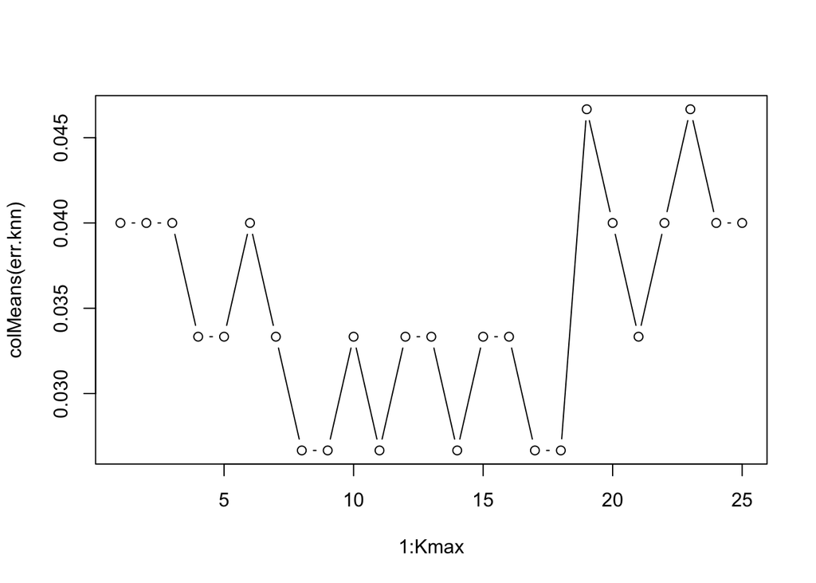

```r
V = 15
N = nrow(X)
folds = rep(1:V,N/V)
Kmax = 25
err.knn = matrix(NA,V,Kmax)
for (v in 1:V){
   # Splitting of the data between learning and valid. sets
   X.learn = X[folds!=v,]
   Y.learn = Y[folds!=v]
   X.val = X[folds==v,]
   Y.val = Y[folds==v]

   # Learn the classifier
   for (k in 1:Kmax){
      yhat = knn(X.learn,X.val,Y.learn,k)
      err.knn[v,k] = sum(yhat != Y.val) / length(Y.val)
   }
}
plot(1:Kmax,colMeans(err.knn),type='b')
```